# What We Watched: Exploring Netflix Viewing Data

Netflix rode a massive wave during the pandemic, turning from a casual entertainment option into a daily utility for millions. But that easy growth era is over. Today, Netflix operates in a crowded arena packed with deep-pocketed legacy rivals, subscriber fatigue, and constantly shifting viewer habits. This project dives straight into Netflix’s official semi-annual engagement datasets. By mapping out real consumption patterns, breaking down title distributions, tracking content runtimes, and analyzing the shifting balance between movies and series, we can derive a clear strategy for optimizing content investment, maximizing viewer retention, and sustaining long-term growth in a volatile market.

```r
# Data and library loading
load_netflix_data <- function(){

  library(tidyverse)
  library(dplyr)
  library(stringr)
  library(rvest)
  library(readxl)
  library(fs)
  library(gt)
  library(skimr)
  library(scales)

  data_dir <- path("data", "mp01")

  if(!dir_exists(data_dir)){
    dir_create(data_dir, showWarnings=FALSE, recurse=TRUE)
  }

  NETFLIX_URLS <- list(
    `2023H1` = "https://about.netflix.com/news/what-we-watched-a-netflix-engagement-report",
    `2023H2` = "https://about.netflix.com/news/what-we-watched-the-second-half-of-2023",
    `2024H1` = "https://about.netflix.com/news/what-we-watched-the-first-half-of-2024",
    `2024H2` = "https://about.netflix.com/news/what-we-watched-the-second-half-of-2024",
    `2025H1` = "https://about.netflix.com/news/what-we-watched-the-first-half-of-2025",
    `2025H2` = "https://about.netflix.com/news/what-we-watched-the-second-half-of-2025",
    `2026H1` = "https://about.netflix.com/news/what-we-watched-the-first-half-of-2026"
  )

  download_if_needed <- function(url, local){
    if(!file_exists(local)){
      download.file(url, local, quiet = TRUE, mode = "wb")
    }

    return(local)
  }

  NETFLIX_URLS |>
    map(read_html) |>
    map(html_element, xpath = "//a[contains(@href, '.xlsx')]") |>
    map_chr(html_attr, "href") |>
    enframe("period", "url") |>
   mutate(path = path(data_dir, paste0(period, ".xlsx")),
          path = map2(url, path, download_if_needed),
          data = map(path, read_excel, skip=3, na="*"),
          data = map(data, \(x) x |> mutate(`Release Date` = as.Date(`Release Date`)))) |>
    unnest(data) |>
    select(-url, -path) |>
    mutate(year=str_sub(period, 1, 4),
           half=str_sub(period, start=6),
           period_start = make_date(year, if_else(half==1, 1, 7), 1),
           period_end = make_date(year, if_else(half==1, 6, 12), if_else(half==1, 30, 31))) |>
    filter(!is.na(`Hours Viewed`)) |>
    mutate(live_event = !is.na(Runtime) & str_detect(Runtime, "\\d+:\\d+\\*"),
           clean_time = str_remove(Runtime, fixed("*")),
           Runtime = 60 * hour(hm(clean_time)) + minute(hm(clean_time))) |>
    select(-clean_time) |>
    mutate(Runtime = coalesce(Runtime, mean(Runtime, na.rm=TRUE)),
           .by=Title,
           Title = stringi::stri_trans_general(Title, "Latin-ASCII"),
           Title = str_remove(Title, " // .*"),
           Title = str_remove(Title, "[^[:ascii:]].*"),
           Title = str_trim(Title)) |>
    filter_out(Title == "") |>
    select(year,
           period,
           period_start,
           period_end,
           Title,
           -half,
           Runtime,
           Views,
           `Hours Viewed`,
           `Release Date`,
           `Available Globally?`,
           live_event)
}

NETFLIX_DATA <- load_netflix_data()

# Then standardize column names, cast variables to appropriate data types, and run preliminary verification checks on missing values, duplicate entries, and headline viewership metrics

NETFLIX_DATA <- NETFLIX_DATA |>
  rename(
    title = Title,
    runtime = Runtime,
    views = Views,
    hours_viewed = `Hours Viewed`,
    release_date = `Release Date`,
    available_globally = `Available Globally?`
  ) |>
  mutate(
    year = as.integer(year),
    available_globally = available_globally == "Yes"
  )

glimpse(NETFLIX_DATA)

NETFLIX_DATA |> slice_sample(n = 10)
skim(NETFLIX_DATA)

NETFLIX_DATA |>
  summarise(
    missing_hours = sum(is.na(hours_viewed)),
    missing_runtime = sum(is.na(runtime)),
    missing_release_date = sum(is.na(release_date)),
    missing_global_flag = sum(is.na(available_globally))
  )

NETFLIX_DATA |>
  count(period, title) |>
  filter(n > 1)

# Next, we look at the big picture by calculating a few summary numbers—including the overall date range, total unique shows, viewing totals for major franchises, how much viewing time goes to the top shows, and how widely available content is worldwide.

date_range <- NETFLIX_DATA |>
  summarise(
    first_period = min(period_start, na.rm = TRUE),
    last_period = max(period_end, na.rm = TRUE)
  )

n_titles <- NETFLIX_DATA |>
  summarise(n = n_distinct(title)) |>
  pull(n)

bridgerton_hours <- NETFLIX_DATA |>
  filter(str_detect(title, regex("Bridgerton", ignore_case = TRUE))) |>
  summarise(total = sum(hours_viewed, na.rm = TRUE)) |>
  pull(total)

stranger_things_hours <- NETFLIX_DATA |>
  filter(str_detect(title, regex("Stranger Things", ignore_case = TRUE))) |>
  filter(!str_detect(title, regex("Beyond Stranger Things", ignore_case = TRUE))) |>
  filter(!str_detect(title, regex("Tales from", ignore_case = TRUE))) |>
  filter(!str_detect(title, regex("Fireplace", ignore_case = TRUE))) |>
  summarise(total = sum(hours_viewed, na.rm = TRUE)) |>
  pull(total)

top_2026h1_share <- NETFLIX_DATA |>
  filter(period == "2026H1") |>
  mutate(total_period_hours = sum(hours_viewed, na.rm = TRUE)) |>
  slice_max(hours_viewed, n = 10, with_ties = FALSE) |>
  summarise(
    share = sum(hours_viewed, na.rm = TRUE) / first(total_period_hours)
  ) |>
  pull(share)

global_availability <- NETFLIX_DATA |>
  summarise(
    title_share = mean(available_globally, na.rm = TRUE),
    hours_share = sum(hours_viewed[available_globally], na.rm = TRUE) /
      sum(hours_viewed, na.rm = TRUE)
  )

date_range
n_titles
bridgerton_hours
stranger_things_hours
top_2026h1_share
global_availability
```

[output not shown]

Diving into the data, this collection covers the period from 2023-01-01 to 2026-06-30, cataloging a whopping 24,427 distinct titles. To put some of our collective binge-watching habits into perspective, the *Bridgerton* universe pulled in a staggering 4,862,800,000 hours of viewing. Meanwhile, the five core seasons of *Stranger Things*—keeping it strictly to the main story and leaving out extras like *Beyond Stranger Things*, *Tales from ’85*, and the *Fireplace*—racked up 5,548,500,000 hours.

```r
top_title_by_period <- NETFLIX_DATA |>
  group_by(period) |>
  mutate(period_total_hours = sum(hours_viewed, na.rm = TRUE)) |>
  slice_max(hours_viewed, n = 1, with_ties = FALSE) |>
  ungroup() |>
  mutate(viewership_share = hours_viewed / period_total_hours) |>
  select(period, title, hours_viewed, viewership_share) |>
  arrange(period)

top_title_by_period |>
  gt() |>
  cols_label(
    period = "Reporting period",
    title = "Top title",
    hours_viewed = "Hours viewed",
    viewership_share = "Share of viewing"
  ) |>
  fmt_number(columns = hours_viewed, decimals = 0) |>
  fmt_percent(columns = viewership_share, decimals = 2) |>
  tab_header(
    title = "Netflix's Most-Watched Title in Each Period",
    subtitle = "Ranked by reported global viewing hours"
  )
```

Netflix's Most-Watched Title in Each Period

Ranked by reported global viewing hours

| Reporting period | Top title | Hours viewed | Share of viewing |
| --- | --- | --- | --- |
| 2023H1 | The Night Agent: Season 1 | 812,100,000 | 0.87% |
| 2023H2 | King the Land: Limited Series | 630,200,000 | 0.97% |
| 2024H1 | Bridgerton: Season 3 | 733,800,000 | 1.08% |
| 2024H2 | Squid Game: Season 2 | 619,900,000 | 0.91% |
| 2025H1 | Squid Game: Season 2 | 840,300,000 | 1.18% |
| 2025H2 | Wednesday: Season 2 | 964,100,000 | 1.35% |
| 2026H1 | Bridgerton: Season 4 | 889,800,000 | 1.20% |

The top spot on Netflix was constantly up for grabs across different reporting windows, with powerhouse hits like Bridgerton, Squid Game, and Wednesday regularly battling for the crown. Even at peak popularity, the single leading title usually claimed between 0.87% and 1.35% of total viewing time. That peak occurred during the second half of 2025. Still, these small percentages prove that viewership is spread across a massive library; which shows that while giant cultural hits are essential, no single show carries the entire platform alone.

```r
catalog_by_period <- NETFLIX_DATA |>
  distinct(period, title, .keep_all = TRUE) |>
  group_by(period) |>
  summarise(
    number_of_titles = n_distinct(title),
    total_runtime_hours = sum(runtime, na.rm = TRUE) / 60,
    .groups = "drop"
  ) |>
  arrange(period)

catalog_by_period |>
  gt() |>
  cols_label(
    period = "Period",
    number_of_titles = "Unique titles",
    total_runtime_hours = "Total runtime (hours)"
  ) |>
  fmt_number(columns = c(number_of_titles, total_runtime_hours), decimals = 0) |>
  tab_header(
    title = "Netflix's Reported Catalog Over Time",
    subtitle = "Unique title strings and summed runtime"
  )
```

Netflix's Reported Catalog Over Time

Unique title strings and summed runtime

| Period | Unique titles | Total runtime (hours) |
| --- | --- | --- |
| 2023H1 | 18,126 | 43,610 |
| 2023H2 | 6,574 | 50,001 |
| 2024H1 | 6,775 | 51,651 |
| 2024H2 | 6,854 | 53,443 |
| 2025H1 | 7,473 | 58,058 |
| 2025H2 | 7,712 | 59,403 |
| 2026H1 | 8,163 | 62,554 |

The raw number of listed titles experienced a sharp dip early on, dropping from 18,126 in the first half of 2023 down to 6,574 in second half of 2023, before climbing back up to 8,163 during the first half of 2026. Intriguingly, total runtime actually went in the opposite direction, expanding from 43,610 to 62,554 hours over that same stretch. This indicates that while the catalog contained fewer titles than it did back in early 2023, the actual volume of watchable content kept growing. Because of that initial drop in title count, it pays to be careful when reading into early platform trends, but the overarching takeaway is clear: total screen time in the catalog expanded steadily over time.

```r
consistent_titles <- NETFLIX_DATA |>
  group_by(title) |>
  summarise(
    periods_present = n_distinct(period),
    mean_hours = mean(hours_viewed, na.rm = TRUE),
    min_hours = min(hours_viewed, na.rm = TRUE),
    sd_hours = sd(hours_viewed, na.rm = TRUE),
    .groups = "drop"
  ) |>
  filter(periods_present >= 5) |>
  arrange(desc(mean_hours)) |>
  slice_head(n = 10)

consistent_titles |>
  gt() |>
  cols_label(
    title = "Title",
    periods_present = "Periods present",
    mean_hours = "Average hours",
    min_hours = "Minimum hours",
    sd_hours = "Standard deviation"
  ) |>
  fmt_number(columns = c(mean_hours, min_hours, sd_hours), decimals = 0) |>
  tab_header(
    title = "Titles With Sustained Viewership",
    subtitle = paste(
      "Top ten by mean viewing hours among titles observed",
      "in at least five periods"
    )
  )
```

Titles With Sustained Viewership

Top ten by mean viewing hours among titles observed in at least five periods

| Title | Periods present | Average hours | Minimum hours | Standard deviation |
| --- | --- | --- | --- | --- |
| Bridgerton: Season 3 | 5 | 246,380,000 | 61,800,000 | 278,035,766 |
| The Night Agent: Season 1 | 7 | 222,157,143 | 48,100,000 | 265,460,297 |
| Queen of Tears: Limited Series | 5 | 220,660,000 | 61,100,000 | 262,317,676 |
| Stranger Things 4 | 7 | 207,385,714 | 97,100,000 | 171,675,823 |
| Wednesday: Season 1 | 7 | 193,628,571 | 51,500,000 | 163,322,745 |
| King the Land: Limited Series | 7 | 192,085,714 | 35,200,000 | 199,743,973 |
| True Beauty: Limited Series | 6 | 178,650,000 | 132,200,000 | 58,312,597 |
| Fool Me Once: Limited Series | 5 | 177,520,000 | 18,100,000 | 287,333,077 |
| Ginny & Georgia: Season 2 | 7 | 162,500,000 | 45,000,000 | 225,415,069 |
| ONE PIECE: Season 1 | 6 | 158,333,333 | 42,900,000 | 193,003,240 |

Bridgerton Season 3 led the pack in average viewing hours among top performers, with The Night Agent Season 1 and Queen of Tears close behind. A handful of fan favorites maintained a steady presence across all seven reporting periods, indicating recurring viewership. However, high average viewing does not necessarily imply consistency, as some titles had much larger standard deviations. For example, Fool Me Once showed substantially more variation than True Beauty. This is an important distinction that helps identify titles that repeatedly attract viewers versus those whose success fluctuates.

```r
content_mix <- NETFLIX_DATA |>
  mutate(
    content_type = if_else(
      coalesce(
        str_detect(title, regex("Season", ignore_case = TRUE)),
        FALSE
      ) | coalesce(runtime > 240, FALSE),
      "TV show",
      "Movie"
    )
  ) |>
  group_by(period, content_type) |>
  summarise(
    hours_viewed = sum(hours_viewed, na.rm = TRUE),
    .groups = "drop"
  ) |>
  group_by(period) |>
  mutate(
    share_of_viewing = hours_viewed / sum(hours_viewed)
  ) |>
  ungroup()

content_mix |>
  gt() |>
  cols_label(
    period = "Period",
    content_type = "Content type",
    hours_viewed = "Hours viewed",
    share_of_viewing = "Share of viewing"
  ) |>
  fmt_number(columns = hours_viewed, decimals = 0) |>
  fmt_percent(columns = share_of_viewing, decimals = 2) |>
  tab_header(
    title = "Viewing Mix: Television and Movies",
    subtitle = "Classification based on title names and runtime"
  )
```

Viewing Mix: Television and Movies

Classification based on title names and runtime

| Period | Content type | Hours viewed | Share of viewing |
| --- | --- | --- | --- |
| 2023H1 | Movie | 28,797,300,000 | 30.83% |
| 2023H1 | TV show | 64,610,300,000 | 69.17% |
| 2023H2 | Movie | 2,738,100,000 | 4.22% |
| 2023H2 | TV show | 62,192,900,000 | 95.78% |
| 2024H1 | Movie | 2,931,600,000 | 4.30% |
| 2024H1 | TV show | 65,312,700,000 | 95.70% |
| 2024H2 | Movie | 2,411,200,000 | 3.54% |
| 2024H2 | TV show | 65,768,700,000 | 96.46% |
| 2025H1 | Movie | 3,483,800,000 | 4.90% |
| 2025H1 | TV show | 67,627,000,000 | 95.10% |
| 2025H2 | Movie | 3,740,200,000 | 5.24% |
| 2025H2 | TV show | 67,643,100,000 | 94.76% |
| 2026H1 | Movie | 3,902,300,000 | 5.25% |
| 2026H1 | TV show | 70,431,300,000 | 94.75% |

TV series comfortably dominated Netflix across every single reporting window. Back during the first half of 2023, television programming claimed 69.17% of total watch time—a figure that surged to 95.78% in the period of July–December of 2023. From that point on, TV shows locked down a dominant baseline, consistently holding over 94% of subscriber attention. Movies, by contrast, made up a surprisingly slim slice of the pie, especially after early 2023.

```r
live_comparison <- NETFLIX_DATA |>
  mutate(
    content_type = if_else(
      live_event, "Live event", "Prerecorded content"
    )
  ) |>
  group_by(period, content_type) |>
  summarise(
    title_count = n_distinct(title),
    mean_hours = mean(hours_viewed , na.rm = TRUE),
    median_hours = median(hours_viewed , na.rm = TRUE),
    top_tier_hours = quantile(
      hours_viewed , probs = 0.90, na.rm = TRUE, names = FALSE
    ),
    total_hours = sum(hours_viewed, na.rm = TRUE),
    .groups = "drop"
  )

live_comparison |>
  gt() |>
  cols_label(
    period = "Period",
    content_type = "Content category",
    title_count = "Number of titles",
    mean_hours = "Mean hours",
    median_hours = "Median hours",
    top_tier_hours = "90th percentile",
    total_hours = "Total hours"
  ) |>
  fmt_number(
    columns = c(mean_hours, median_hours, top_tier_hours, total_hours),
    decimals = 0
  ) |>
  tab_header(
    title = "Live Events and Prerecorded Content",
    subtitle = "Typical, upper-tail, and aggregate viewing"
  )
```

Live Events and Prerecorded Content

Typical, upper-tail, and aggregate viewing

| Period | Content category | Number of titles | Mean hours | Median hours | 90th percentile | Total hours |
| --- | --- | --- | --- | --- | --- | --- |
| 2023H1 | Prerecorded content | 18126 | 5,133,414 | 700,000 | 11,500,000 | 93,407,600,000 |
| 2023H2 | Prerecorded content | 6574 | 9,845,489 | 2,500,000 | 24,060,000 | 64,931,000,000 |
| 2024H1 | Prerecorded content | 6775 | 10,040,356 | 2,600,000 | 26,040,000 | 68,244,300,000 |
| 2024H2 | Live event | 3 | 78,766,667 | 400,000 | 188,640,000 | 236,300,000 |
| 2024H2 | Prerecorded content | 6851 | 9,884,143 | 2,500,000 | 24,400,000 | 67,943,600,000 |
| 2025H1 | Live event | 88 | 3,412,500 | 1,900,000 | 7,420,000 | 300,300,000 |
| 2025H1 | Prerecorded content | 7385 | 9,550,917 | 2,300,000 | 23,600,000 | 70,810,500,000 |
| 2025H2 | Live event | 102 | 2,194,118 | 1,200,000 | 5,990,000 | 223,800,000 |
| 2025H2 | Prerecorded content | 7610 | 9,318,950 | 2,400,000 | 21,950,000 | 71,159,500,000 |
| 2026H1 | Live event | 117 | 2,933,333 | 1,900,000 | 6,240,000 | 343,200,000 |
| 2026H1 | Prerecorded content | 8046 | 9,168,575 | 2,300,000 | 21,400,000 | 73,990,400,000 |

The Gini coefficient is an economic measurement of inequality. In the context of this analysis of Netflix: A Gini coefficient of 0.0 would mean every single title on Netflix would have pulled in the exact same number of viewing hours where an obscure documentary gets the exact same traffic as Stranger Things. And a coefficient of 1.0 would mean that one single title would account for 100% of all viewing hours on the entire platform.

```r
# Define a function to calculate the Gini coefficient
gini_coefficient <- function(x) {
  x <- x[!is.na(x) & x >= 0]
  n <- length(x)

  if (n == 0 || sum(x) == 0) {
    return(NA_real_)
  }

  x <- sort(x)

  (2 * sum(seq_along(x) * x) / (n * sum(x))) - ((n + 1) / n)
}

# Test the function

example_income <- c(20000, 200000, 0, 50000, 40000)
gini_coefficient(example_income)
```

[output not shown]

```r
# Next, we examine how unevenly viewership is distributed across titles in each reporting period by calculating Gini coefficients—both for total viewing hours and for runtime-normalized hours—and display the results in a summary table.

gini_by_period <- NETFLIX_DATA |>
  mutate(hours_per_runtime_minute = hours_viewed / runtime) |>
  group_by(period) |>
  summarise(
    title_count = n_distinct(title),
    gini_hours = gini_coefficient(hours_viewed),
    gini_normalized = gini_coefficient(hours_per_runtime_minute),
    .groups = "drop"
  ) |>
  arrange(period)

gini_by_period |>
  gt() |>
  cols_label(
    period = "Reporting period",
    title_count = "Number of titles",
    gini_hours = "Gini: viewing hours",
    gini_normalized = "Gini: hours per runtime minute"
  ) |>
  fmt_number(columns = c(gini_hours, gini_normalized), decimals = 3) |>
  tab_header(
    title = "Concentration of Netflix Viewing",
    subtitle = "Inequality across titles in each reporting period"
  )
```

Concentration of Netflix Viewing

Inequality across titles in each reporting period

| Reporting period | Number of titles | Gini: viewing hours | Gini: hours per runtime minute |
| --- | --- | --- | --- |
| 2023H1 | 18126 | 0.814 | 0.701 |
| 2023H2 | 6574 | 0.738 | 0.704 |
| 2024H1 | 6775 | 0.742 | 0.708 |
| 2024H2 | 6854 | 0.746 | 0.715 |
| 2025H1 | 7473 | 0.751 | 0.724 |
| 2025H2 | 7712 | 0.750 | 0.716 |
| 2026H1 | 8163 | 0.755 | 0.715 |

Looking at the Gini coefficients (which range from 0.74 to 0.81), it’s clear that viewership on Netflix is pretty top-heavy. A small tier of blockbuster hits claims a massive, disproportionate share of total audience attention. This concentration peaked in January–June of 2023 before leveling off into a stable pattern in subsequent years. When calculating concentration based on viewing hours per minute of runtime, the Gini scores drop slightly, which means program length does play a role in inflating total viewing numbers. But, even after accounting for episode length, subscriber attention remains heavily concentrated around a select group of fan favorites.

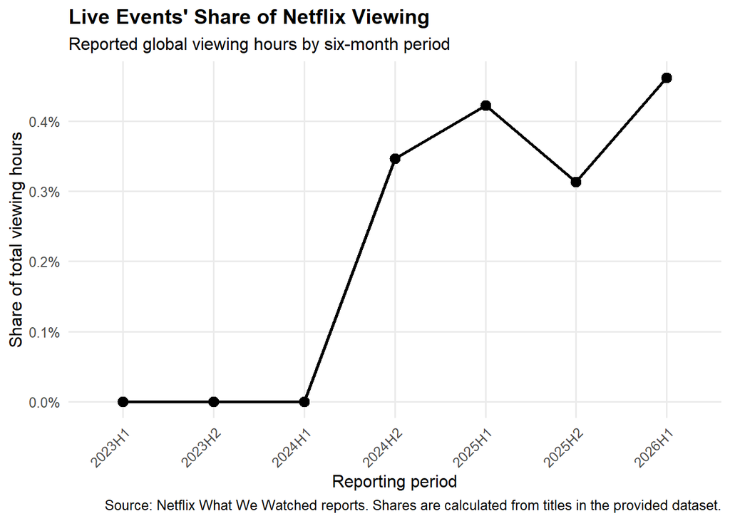

```r
live_share_by_period <- NETFLIX_DATA |>
  group_by(period) |>
  summarise(
    total_hours = sum(hours_viewed, na.rm = TRUE),
    live_hours = sum(hours_viewed[live_event], na.rm = TRUE),
    live_share = live_hours / total_hours,
    .groups = "drop"
  ) |>
  arrange(period)

live_share_plot <- live_share_by_period |>
  ggplot(aes(x = period, y = live_share, group = 1)) +
  geom_line(linewidth = 1) +
  geom_point(size = 3) +
  scale_y_continuous(labels = scales::label_percent(accuracy = 0.1)) +
  labs(
    title = "Live Events' Share of Netflix Viewing",
    subtitle = "Reported global viewing hours by six-month period",
    x = "Reporting period",
    y = "Share of total viewing hours",
    caption = paste(
      "Source: Netflix What We Watched reports.",
      "Shares are calculated from titles in the provided dataset."
    )
  ) +
  theme_minimal(base_size = 12) +
  theme(
    plot.title = element_text(face = "bold"),
    axis.text.x = element_text(angle = 45, hjust = 1),
    panel.grid.minor = element_blank()
  )

live_share_plot
```

Looking at the trajectory of live programming on Netflix, live events were effectively non-existent from the first half of 2023 through early 2024 (~0%). That changed abruptly in July–December of 2024, when live content made its first real footprint at 0.35% of total watch time. Growth continued into the first half of 2025 (0.42%), followed by a mild contraction in the second half of 2025 (0.32%). By January–June of 2026, live viewing climbed to a record high of 0.46%. So while live broadcasts have clearly become a deliberate part of Netflix’s content strategy since late 2024, they remain a tiny drop in the bucket—never crossing the 0.5% threshold of total platform viewership.

# Analytical Strategy Memo: Evaluating Netflix Viewing Trends for 2027 and Beyond

### Executive Summary

As Netflix continues to refine its platform strategy, looking back at historical viewing data gives us a clear window into how subscriber attention actually moves across formats, licensing structures, and content types. Drawing on viewing patterns from **January 2023 through June 2026**, this memo outlines structural shifts in the catalog and offers practical, data-backed guidance for future original content investments.

### Key Analytical Findings

#### 2. Catalog Efficiency: Quality and Depth Over Raw Quantity

A major shift in Netflix’s library shows that you don’t need a bloated title count to keep aggregate watch time growing. The total number of reported titles dropped drastically from **18,126** in the first half of 2023 down to **6,574** in the second half of the year, before rebounding slightly to **8,163** by the first half of 2026. Yet despite carrying far fewer individual titles than in 2023, total runtime in the catalog steadily expanded from **43,610 hours to 62,554 hours**. Instead of spreading resources thin across thousands of short-lived titles, the platform shifted focus toward longer, deeper content like multi-season series.

#### 3. The Power of Worldwide Availability

Global distribution makes a massive difference in how efficiently content performs. Titles with worldwide availability make up about **68.6%** of the listed catalog, but they punch far above their weight class by capturing **93.7%** of total viewing hours when weighted by actual viewership. Securing global rights is easily one of the biggest multipliers for a title’s reach.

#### 4. Heavy Hit Concentration vs. Everyday Comfort Shows

Subscriber viewing remains top-heavy, though no single title carries the platform by itself. Gini coefficients hover between **0.74 and 0.81** across reporting periods, confirming that a select group of breakout blockbusters claims a huge slice of overall attention. Massive tentpoles like *Bridgerton*, *Squid Game*, and *Wednesday* usually peak between **0.87% and 1.35%** of total platform viewing hours during their launch windows (hitting a high point in late 2025). But behind those flashy peaks, Netflix relies on a deep bench of steady, reliable performers (like *True Beauty*) to keep watch time steady after high-spike, fast-fading thrillers (like *Fool Me Once*) cool off.

### Strategic Implications for 2027 and Beyond

Looking at the numbers from 2023 through 2026, a few practical rules should shape future content investments:

- **Focus capital on episodic TV:** With episodic series holding **over 94%** of subscriber viewing time, capital allocation should lean heavily into multi-season TV shows over standalone movie acquisitions.
- **Invest in deep engagement over title counts:** Because total runtime grew even as title counts shrank, Netflix should double down on deep, high-engagement series instead of trying to artificially pad the catalog with sheer volume.
- **Make global rights a baseline standard:** Given that global releases account for **nearly 94%** of all watch time despite taking up under 70% of the catalog, securing worldwide rights ought to be a standard requirement in contract negotiations to maximize viewing returns.
- **Maintain a balanced two-part portfolio:** High viewing concentration proves that while big blockbusters bring people through the door, everyday comfort shows are what stop them from canceling. Netflix needs both: **headline-grabbing hits** to attract new subscribers, and **dependable catalog series** to hold their attention month after month.
- **Leverage live events as targeted hooks:** Even though live events still make up **under 0.5%** of total watch time, major live broadcasts create valuable cultural buzz and work exceptionally well as targeted hooks to bring in fresh users.

Combining these moves gives Netflix a well-rounded portfolio—one that plays to its proven strengths and keeps expanding the core products that raw data shows are already making money.

**NoteAI Usage Statement**

AI assistance (Gemini) was utilized during the development of this project in the following capacities:

- **Debugging & Error Resolution:** Used to interpret R error messages, troubleshoot code syntax, and resolve knitting issues within R Markdown.
- **Code Optimization:** Consulted for advice on improving code efficiency, streamlining data manipulation steps, and refining output formatting.
- **Analytical Guidance & Problem-Solving:** Used as a sounding board to brainstorm logical approaches for structuring data interpretations and organizing analytical findings.